# Challenge 1 Simulation and Correlation

Xiang (Sean) Cheng (chengxiang.cn@gmail.com)

June 11, 2016

## Introduction

Revenue growth prediction is an interesting and practical problem. I do have questions because I am new to this type of revenue prediction problem, but I will make some assumptions due to limitted time. In real working environment, we need to communciate to make decisions about the assumptions and parameters. ([More information about the problem](http://htmlpreview.github.com/?https://raw.githubusercontent.com/seanxiangcheng/datachallenge/master/Problemsets/Data_Challenge_Guide.html))

#### Assumptions

1. The question we want to answer is the dependence of total revenue growth on correlation.
2. Correlation can be positive or negative;
   - costomers need both features: positive correlation;
   - costomers need only 1 feature: negative or no correlation;
3. Both features boost the revenue cumulatively (after correlation);
   - The product with more features has higher price;
   - Each feature can generate regular cash flow (by selling disposable consumables) ;
4. Both features are unlikely to decrease revenue.
   - Negative growth rate has very small or no probability;
   - Normal distribution: standard deviation<=0.02;
   - Uniform distribution: min>=0.01;
5. Correlations are in a reasonable range. Here we assume it is between -0.8 and 0.8.

## Task 1: same distributions

In this task, for simplicity, assume both are from the same distribution, either a normal distribution or a uniform distribution.

#### 1. Normal distributions

The 2 functions to generate correlated random normal variables and to examine the mean and correlation matrix.

```r
# function to generate correlated random normal variables
normal_xy <- function(r=0.5, n=1e3, mu=c(0.05, 0.07), var=c(0.02^2, 0.02^2)){
  sigma = matrix(c(var[1], r*prod(sqrt(var)), r*prod(sqrt(var)), var[2]),nrow=2)
  normal_xy = mvrnorm(n=n, mu=mu, Sigma=sigma)
  normal_xy = data.frame(normal_xy)
  names(normal_xy) = c('X', 'Y')
  return(normal_xy)
}
# function to check the mean and correlation of the random variables
check_mean_cor <- function(df_xy){
  mus = apply(df_xy, 2, mean)
  cat("mean of X and Y:\n"); print(mus)
  sigma = cor(df_xy)
  cat("\ncorrelation matrix:\n"); print(sigma)
}
```

A quick check of the 2 functions:

```r
check_mean_cor(normal_xy(r=0.5, n=1e5))
```

```
## mean of X and Y:
##          X          Y
## 0.05001577 0.06998222
##
## correlation matrix:
##           X         Y
## X 1.0000000 0.4992493
## Y 0.4992493 1.0000000
```

Here, we simulate the revenue and plot the 90% confidence interval of the growth rate with both features. The standard deviations are 0.02 and 0.02, respectively.

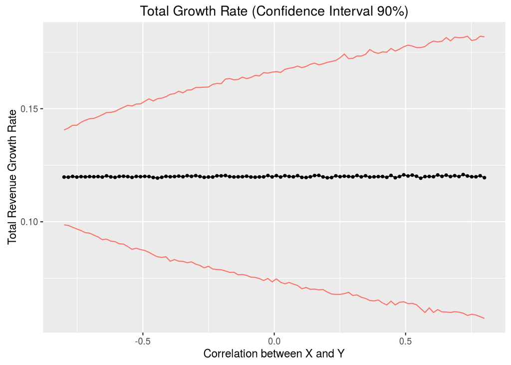

```r
# 100 different correlations
n.obs = 100; CI=0.9;
rs = seq(r.min, r.max, length.out=n.obs)
total.mean = rep(0, n.obs)
CI.low = rep(0, n.obs)
CI.high = rep(0, n.obs)
for(i in 1:n.obs){
  r = rs[i]
  total = rowSums(normal_xy(r=r, n=1e4))
  total.mean[i] = mean(total)
  CI.low[i] = quantile(total, (1-CI)/2.)
  CI.high[i] = quantile(total, (1+CI)/2.)
}
df = data.frame(rs=rs, mean=total.mean, low=CI.low, high=CI.high)
ggplot(df, aes(x=rs , y = mean)) + geom_point(size = 1) + geom_line()+
  geom_line(aes(y = low, colour = "red"))+  geom_line(aes(y = high, colour = "red"))+
  labs(x="Correlation between X and Y",y="Total Revenue Growth Rate", title=paste0("Total Growth Rate (Confidence Interval ", CI*100, "%)") )+ theme(legend.position="none")
```

#### 2. Uniform distributions

In a similar manner, we can also get the revenue prediction of uniformly distributed rates. Instead of using a build-in function, we need to use cholesky decomposition to transform the independent random variables to correlated ones. (Functions are hidden in raw R markdown file by setting ‘echo=FALSE’.) The ranges of uniform distribtuions are [0.03, 0.07] and [0.05, 0.09], respectively.

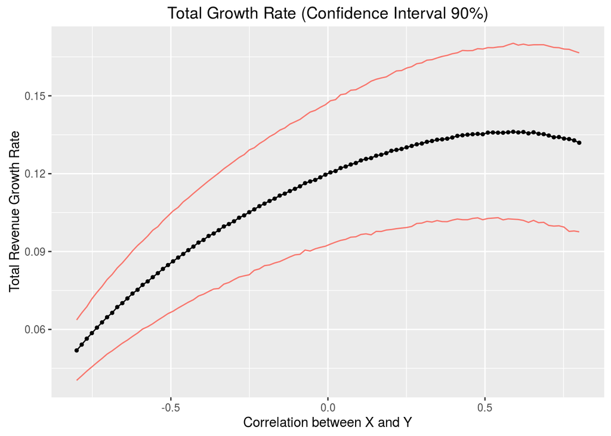

## Task2: different distributions

We here assume the impact of X is normally distributed while the impact of Y is uniformally distributed. The functions are hidden in the raw R markdown file (‘echo=FALSE’).

Test the correlation between the 2 correlated samples.

```r
check_mean_cor(normal_xy(r=0.5, n=1e5))
```

```
## mean of X and Y:
##          X          Y
## 0.04998733 0.07003594
##
## correlation matrix:
##           X         Y
## X 1.0000000 0.5000095
## Y 0.5000095 1.0000000
```

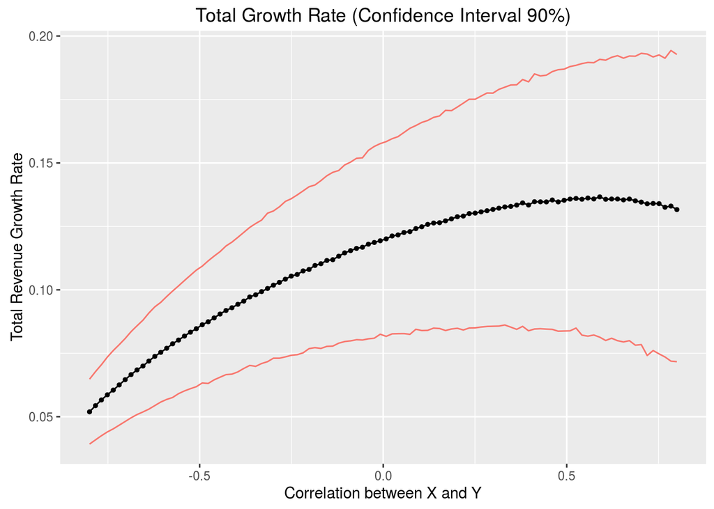

**Note**:

1. **Correlated random variables**: In my research, we use advanced Monte Carlo algorithms, complex networks, and C++ to simulate physical systems. Mostly, we use independent random variables, so I don’t have much experience in generating correlated random variables using R. There may be better ways to do, and I am very intestered to learn. I do hope I can learn new things from a job. The good thing is that I have a soild foundation in statistics, math, and programming. It should be quick for me to learn new things.
2. **Programming languages**: I can use R, Python, and C++. R is chosen here to be consistent with your choice of generating the guide files. I also have experience in interpreting outputs from SAS, STATA, and SPSS. My diverse skill set may make team-work easier.